# Tesla Twitter Data Analysis Report

Create Knowledge Around the Tesla’s Twitter Activity

Alessandro VARNELLI, Venkat JAYANARASIMHAN, Laura EL AOUFIR

04 February 2021

Abstract

This report aims to describe how Tesla, leader on the market of luxurious electric cars, communicates with its followers on Twitter through text mining methods. This analysis focusing on Tesla’s tweets in 2019 and 2020, but also includes information about tweets referencing Tesla.

## What is Tesla?

Tesla, Inc. is an American electric vehicle and clean energy company based in Palo Alto, California. Tesla’s current products include electric cars, battery energy storage from home to grid scale, solar panels and solar roof tiles, as well as other related products and services. (source:https://en.wikipedia.org/wiki/Tesla,_Inc.)

In 2019, Tesla’s revenue was approximately equal to 25 billions and saw a progression of 15% in its year on year sales.

## I. Getting the Twitter Data

### Twitter API

In order to retrieve Twitter data, we needed to first create a developer account from the Twitter platform and extract our personal credentials to create a valid API. Thanks to the “rtweet” package, we were able to extract Tesla’s last 3200 tweets using the get_timelines function. We finally saved this database with a “.rds” extension, using the “mgcv” package.

### Handling the Timeline

The oldest tweets we could get from this database were from 2013. As a result, we decided to subset only the 2019/2020 tweets from this original database. As Tesla’s amount of tweets significantly diminishes in 2020, some parts of the analysis focus only on the 2019 tweets, to be able to gather enough data points to conduct a trustworthy analysis. In total, the Tesla’s Twitter Dataset contains 771 Tweets and 97 features, which are leveraged in this analysis for deriving insights.

### Quick Overview

Volume: 771 Followers: 73,98,637 Retweets: 6,48,332 Favourites: 57,99,519 Replies: 289 Quotes: 0 Twitter Engagement Rate: 0.11%

| user_id | status_id | created_at | screen_name | text |
| --- | --- | --- | --- | --- |
| 13298072 | 1326607188178006016 | 2020-11-11 19:26:15 | Tesla | Order solar panels before the solar tax credit drops at the end of this year. Pair with Powerwall to experience no more blackouts! |
| https://t.co/gvX4KnG2ca |  |  |  |  |
| 13298072 | 1325493014941216768 | 2020-11-08 17:38:55 | Tesla | 20k Superchargers and counting https://t.co/urudyt9Eui |
| 13298072 | 1317251873687113730 | 2020-10-16 23:51:34 | Tesla | There’s no place like home..especially if it has a Solar Roof. |

## II. How Does Tesla Reply to its Customers?

### Response to Personal Vs Business Profiles

Tesla has shown keen focus to respond to Personal twitter profiles comparing to the Business profiles. From 2019, Tesla has addressed a total number of 218 (75%) Personal Accounts and 33 (11%) Business Accounts.

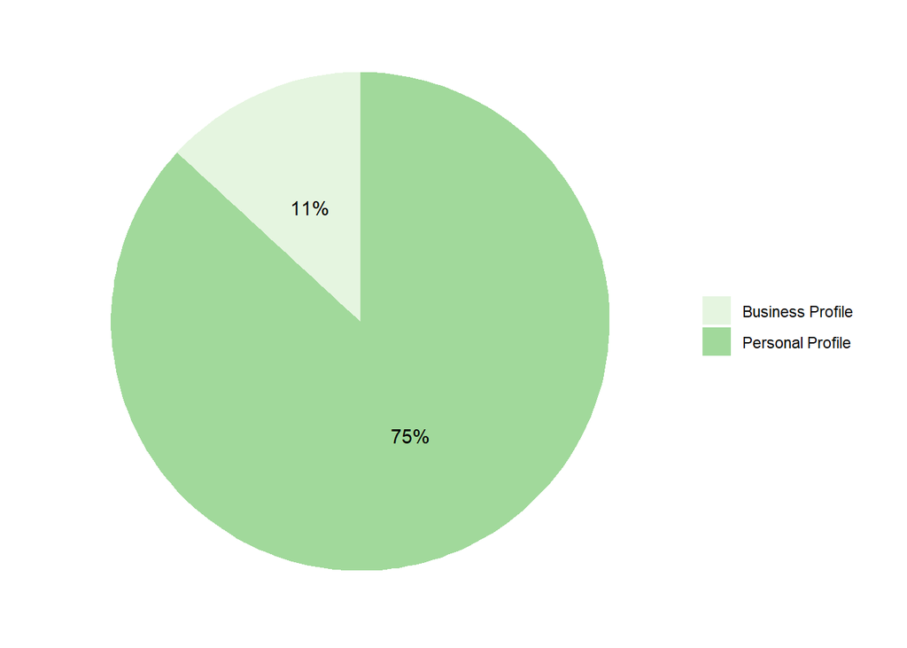

### Response to Mentioned Vs Non-Mentioned Tweets

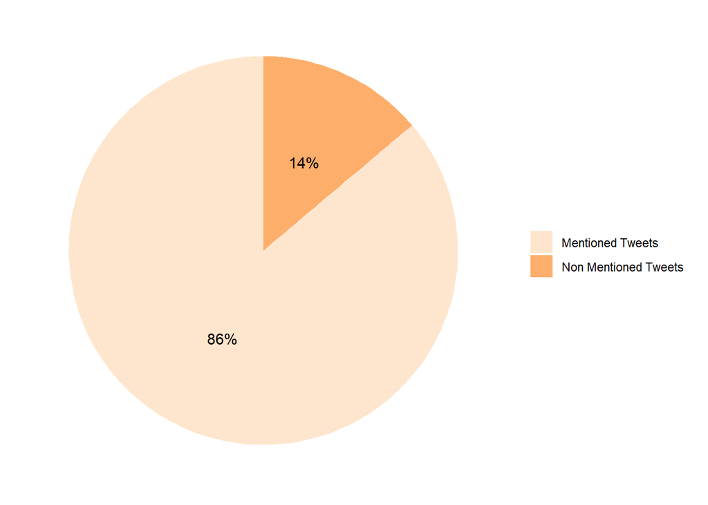

### Response to Positive Vs Negative Vs Neutral Tweets

Tesla prefers to respond to Positive Tweets over Negative ones. Interestingly, Tesla also prefers to respond to Negative Tweets over Neutral Tweets. Since 2019, Tesla has responded to a total number of 156 (61%) positive tweets, 68 (26%) negative tweets and 33 (13%) neutral tweets.

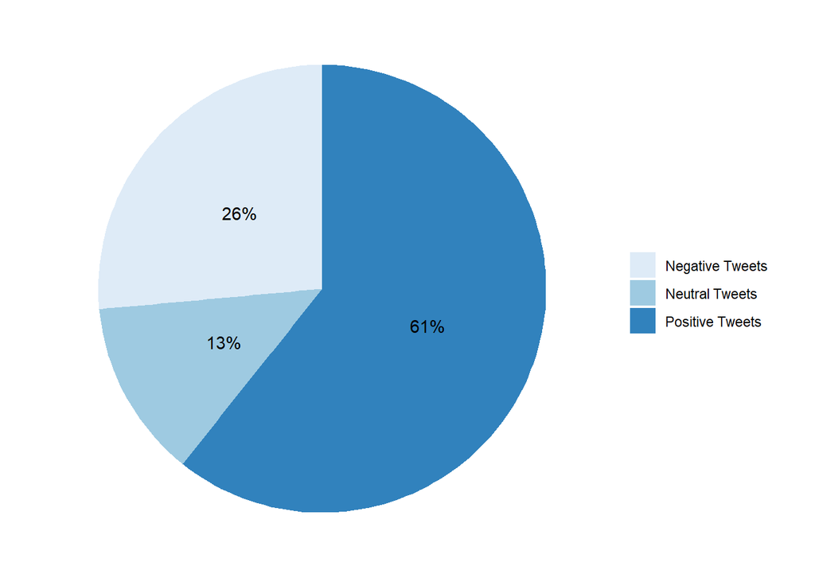

## III. Overall Summary of Tesla’s Tweets

Tesla has an overall volume of 771 Tweets with 73,98,637 followers, 6,48,332 Retweets and 57,99,519 Favourites.

### Twitter Engagement Rate

The twitter engagement rate is calculated based on the retweets, favourites, quotes, replies and followers count.

The average Twitter engagement rate of Tesla is 0.11%. Tesla has a huge scope in increasing its twitter engagement rate by increasing its reply and quote counts.

### Directed Vs Un-Directed Tweets

Based on the Tesla’s Twitter posts, it posts Directed Tweets slightly higher than the Un-Directed posts.

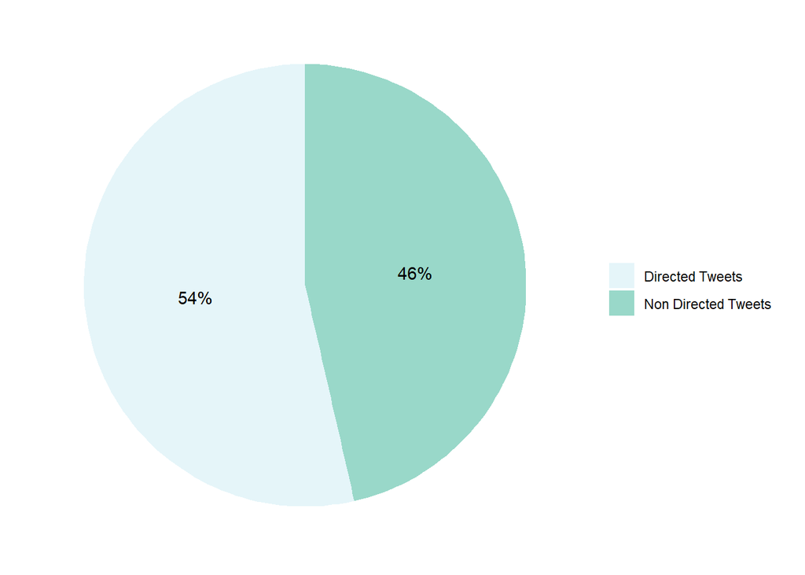

### Number of Tweets over Time

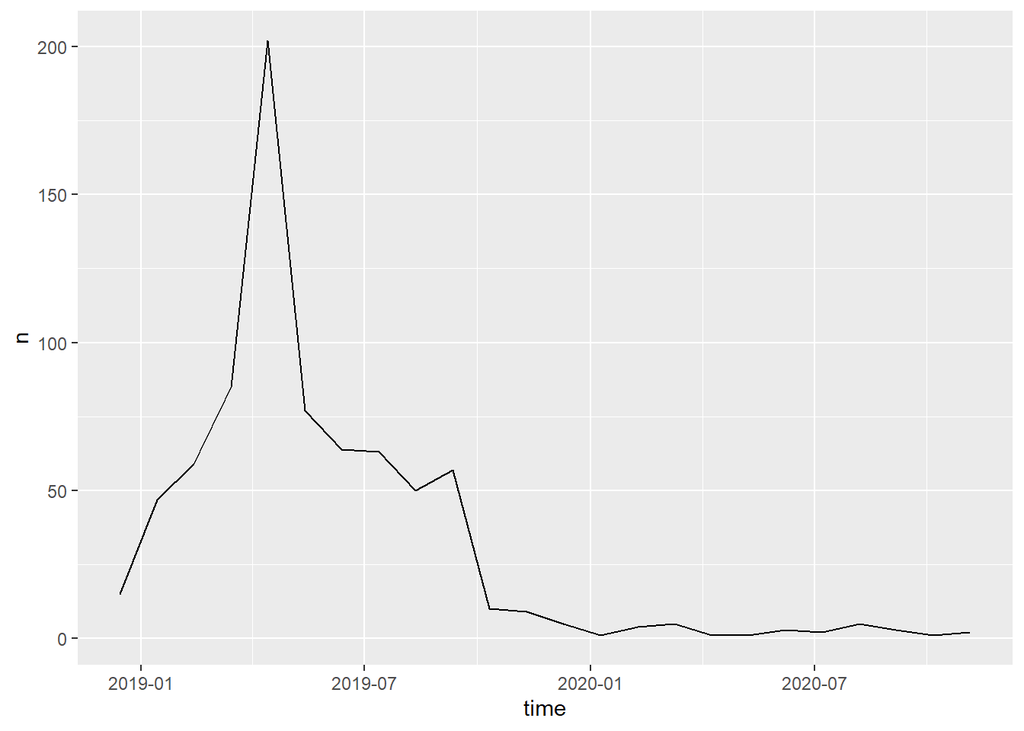

### Tweets Type Distribution

Tesla’s approach to releasing tweets is interesting as it uses only 37% of organic tweets. However, for example, when looking at the SpaceX twitter account, which is a company also directed by Elon Musk, the organic tweets represent more than 75% of the tweeting strategy.

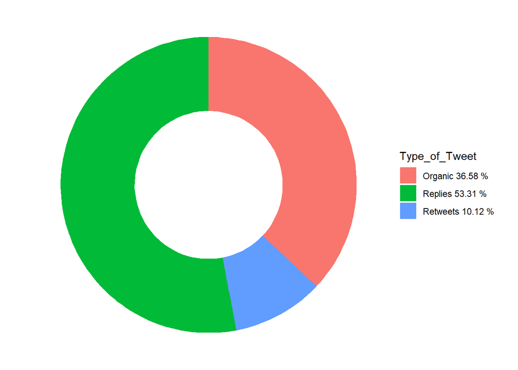

### Tweets Source

Using the “source” variable of the dataset, we are able to understand where the tweets are deployed from. Predominantly, the tweets are released from the “Twitter Web Client” platform, but is it interesting to note that 10% of the tweets are coming from an Apple phone, which could imply that Elon Musk is tweeting 10% of the tweets himself.

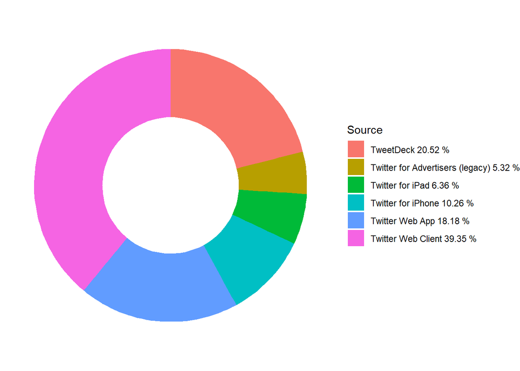

### Tweets Frequency (2019)

This frequency analysis focuses on tweets released in 2019, as the count of 2020 tweets are rather low.

#### By Month

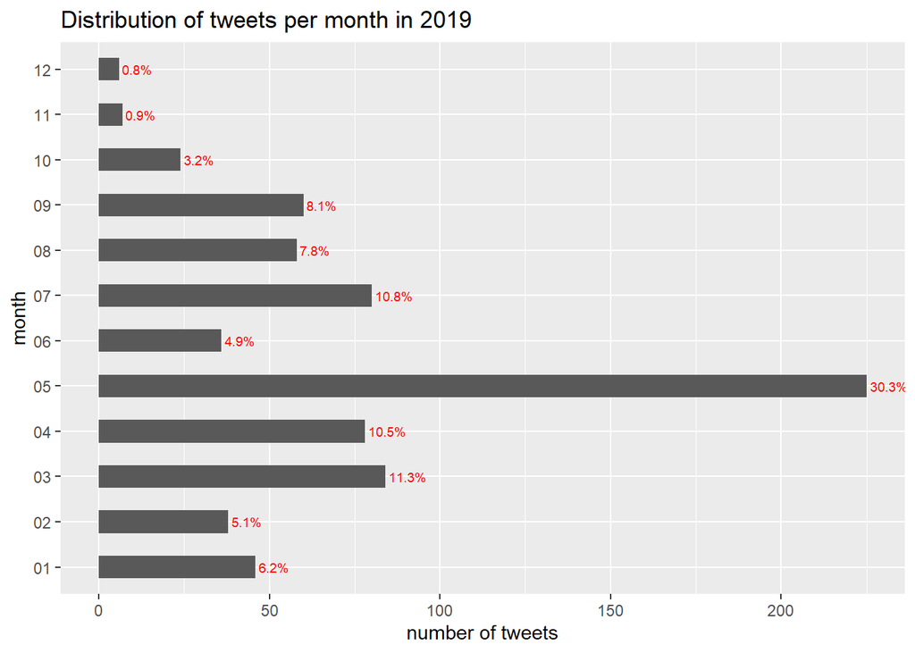

#### By Day

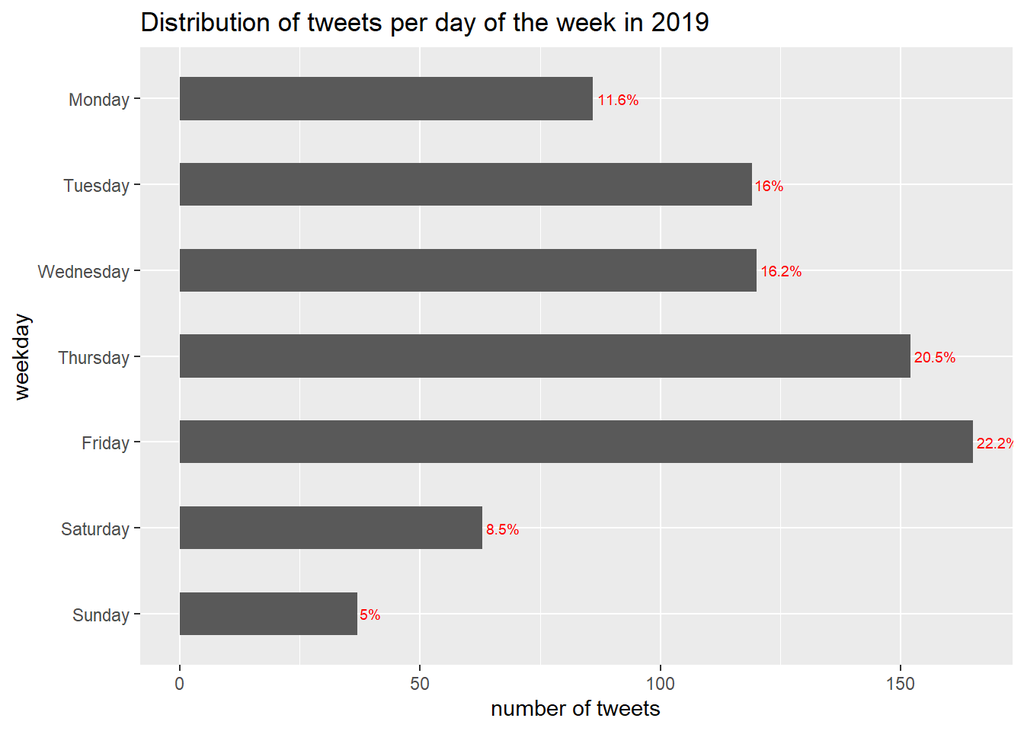

#### By Hour

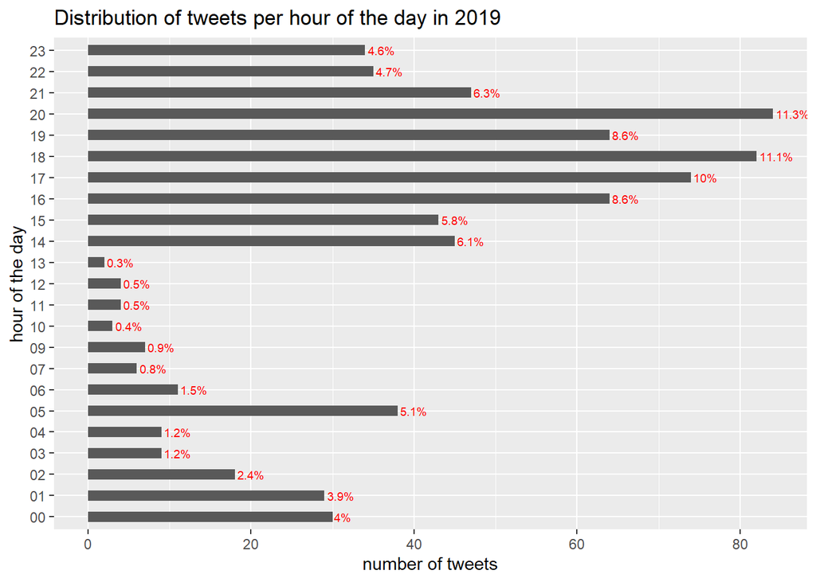

#### Heat Map: Weekly Overview

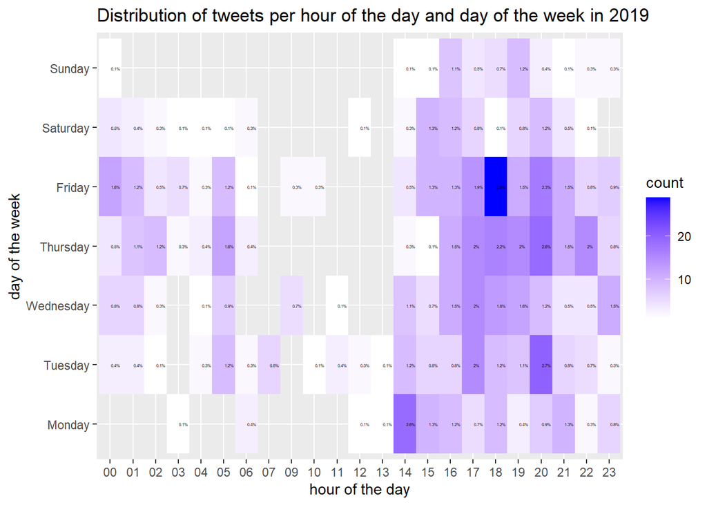

### Use of Emojis (2019)

Tesla uses very few emojis in its tweets. However, the emojis that they use are diverse and quite male connoted.

| text |
| --- |
| Order solar panels before the solar tax credit drops at the end of this year. Pair with Powerwall to experience no more blackouts! |
| https://t.co/gvX4KnG2ca |
| 20k Superchargers and counting https://t.co/urudyt9Eui |
| There’s no place like home..especially if it has a Solar Roof.nThis Kansas ranch got theirs installed in 4 days. |
| In-car footage from Sunday’s Plaid Model S run at Laguna Seca https://t.co/rwQDBFCWoH |
| The only thing beyond Ludicrous is Plaid |
| Tesla Battery Day starts now! |

[figure not shown]

### Most and Least Favorite Tweets

Below are the 5 tweets with the most favorites.

```
## # A tibble: 5 x 1
##   text
##   <chr>
## 1 "Introducing Dog Mode: set a cabin temperature to keep your dog comfortable w~
## 2 "\"I really miss gas stations\" said nobody ever"
## 3 "Your next charging session is going to be SO \U0001f44f MUCH \U0001f44f FUN ~
## 4 "20k Superchargers and counting https://t.co/urudyt9Eui"
## 5 "Showing mom and grandma Autopark @lilduval https://t.co/Zs0zyMD2ma"
```

Below are the 5 tweets that have been retweeted the most.

```
## # A tibble: 5 x 1
##   text
##   <chr>
## 1 "Introducing Dog Mode: set a cabin temperature to keep your dog comfortable w~
## 2 "\"I really miss gas stations\" said nobody ever"
## 3 "Your next charging session is going to be SO \U0001f44f MUCH \U0001f44f FUN ~
## 4 "Model 3s now available\n \nStandard Range: 220mi, $35k\nStandard Range Plus:~
## 5 "Showing mom and grandma Autopark @lilduval https://t.co/Zs0zyMD2ma"
```

Below are the 5 tweets with the least favorites.

```
## # A tibble: 5 x 1
##   text
##   <chr>
## 1 @eliz_banks Should be updated in the next software release
## 2 @marcusklaas Model X has the largest all-glass panoramic windshield in produc~
## 3 @occupylars @elonmusk ✨
## 4 @OnMarsZ @TheElonMasked @JohnnaCrider1 @Wendys ...yes
## 5 @AceFins09 @Lexus do it
```

Below are the 5 tweets that have been retweeted the least.

```
## # A tibble: 5 x 1
##   text
##   <chr>
## 1 @hansteslas ❤️
## 2 @masebastien ❤️
## 3 @occupylars @elonmusk ✨
## 4 @OnMarsZ @TheElonMasked @JohnnaCrider1 @Wendys ...yes
## 5 @AceFins09 @Lexus do it
```

Here, we can picture the number of favorites over time.

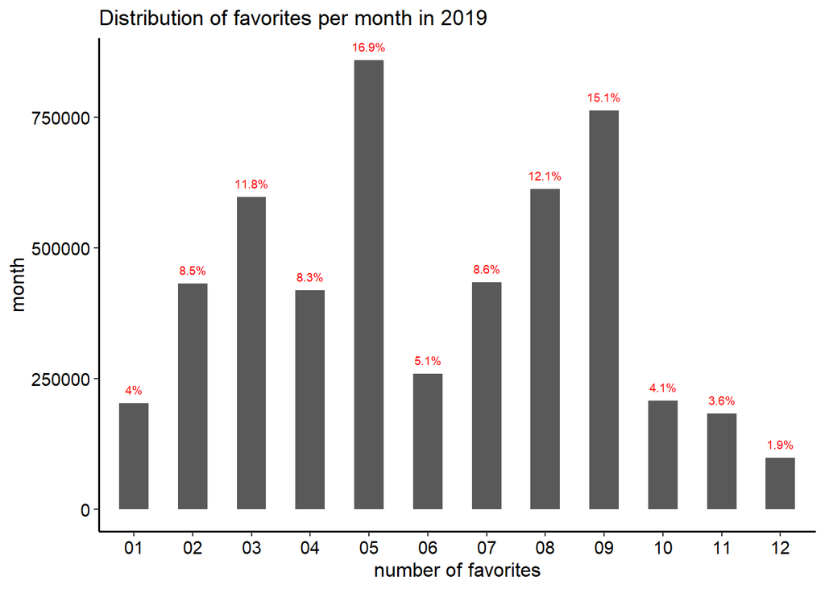

### Use of Images in Tweets

Tesla is using only the ‘photo’ type of media in their tweets. There is no presence of video or gifs.

Over the year 2019, the company used 92 images, which represents approximately 12% of its tweets.

```
## [[1]]
## [1] NA
##
## [[2]]
## [1] "photo"
```

This graph informs us on how Tesla uses images in tweets over the year 2019. We can conclude a certian seasonality in car sales, which we have confirmed by searching on the Internet. The peak seasons for the automobile industry are situated in the late srping and November. The use of images in September tells us that Tesla was surely communicating on their models at that time.

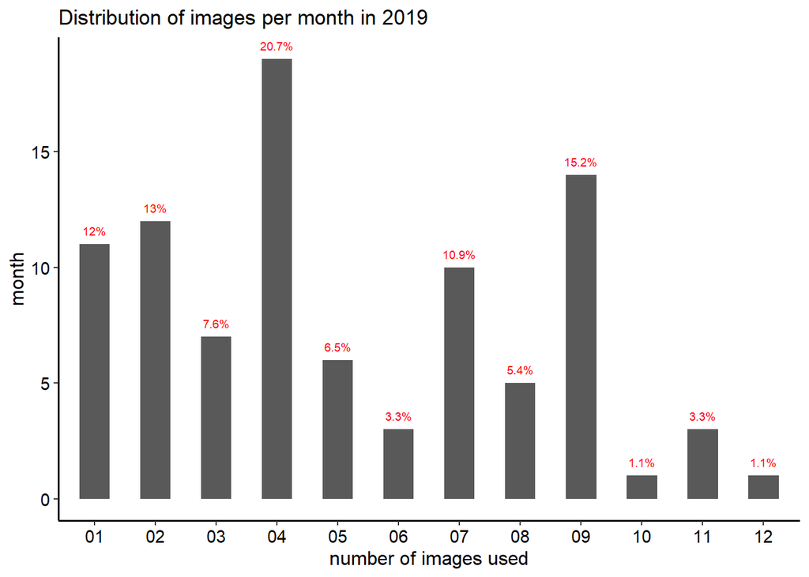

Tesla most retweeted tweet with an image was the following:

[figure not shown]

Tesla least retweeted tweet with an image was the following:

[figure not shown]

## VI. Twitter Users Responding / Approaching Tesla

Tesla boasts a huge follower base in Twitter, thus it attracts more profiles responding to its tweets and also more profiles approaching the company for updates, queries and feedback.

### Accounts Retweeting Tesla’s Tweets

Here is a wordcloud representing the accounts which retweet Tesla’s tweets the most. Wihtout surprises, Elon Musk is predominantly retweeting.

[figure not shown]

### Top Locations of People contacting Tesla

```
## [1] 53
```

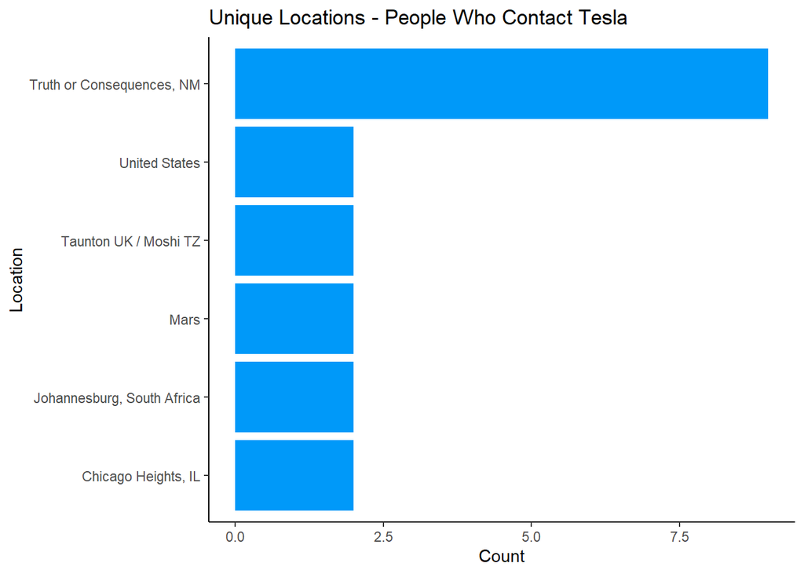

### Top Interests of People contacting Tesla

The people contacting Tesla are majorly interested in topics like Bitcoin, Electric Cars and Technology related news.

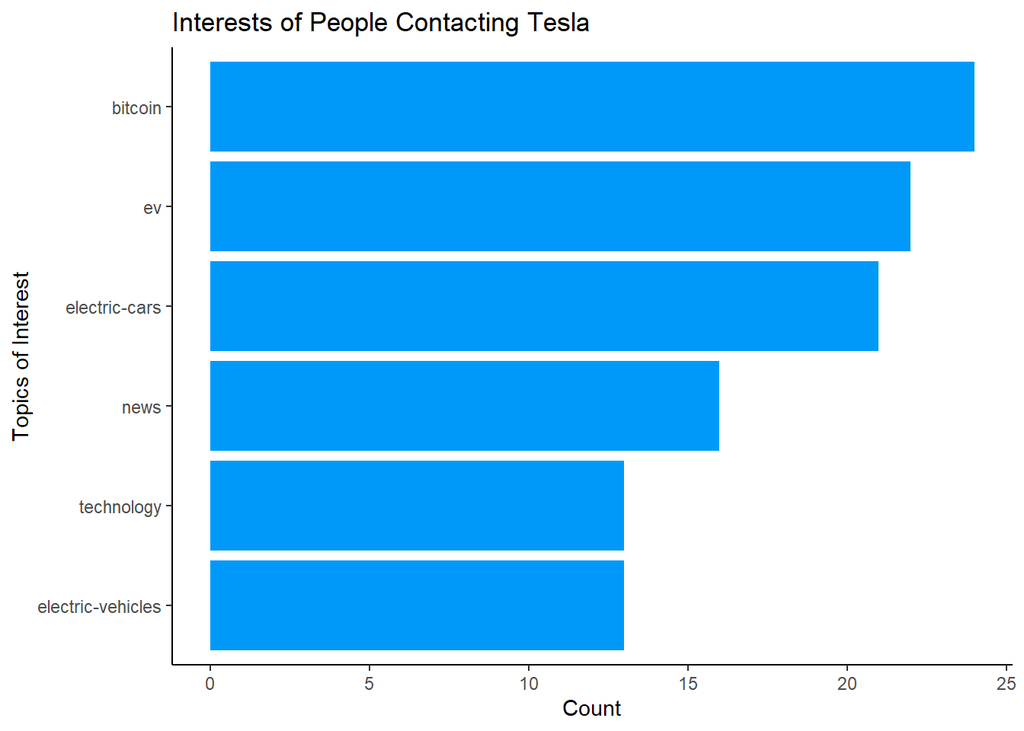

## V. Sentiment Analysis

The main goal of this section is to conduct a sentiment analysis on the contents of Tesla’s tweets, in order to extract a clear idea of the emotion associated to tweets from Tesla and its evolution over time.

To do so, it is of course necessary to clean the data and preprocess the content.

The first step is the removal of punctuation, of symbols and of numbers. At this point what we did was to tokenize all the text for further steps, such as stemming and lemmatization.

```
## [1] "Order solar panels before the solar tax credit drops at the end of this year Pair with Powerwall to experience no more blackouts\nhttpstcogvXKnGca"
## [2] "k Superchargers and counting httpstcourudytEui"
## [3] "Theres no place like homeespecially if it has a Solar Roof\n\nThis Kansas ranch got theirs installed in  days"
## [4] "Incar footage from Sunday’s Plaid Model S run at Laguna Seca httpstcorwQDBFCWoH"
## [5] "The only thing beyond Ludicrous is Plaid"
## [6] "Tesla Battery Day starts now"
```

```
## # A tibble: 5 x 4
##   user_id  status_id       text                                            word
##   <chr>    <chr>           <chr>                                           <chr>
## 1 13298072 13266071881780~ "Order solar panels before the solar tax credi~ order
## 2 13298072 13266071881780~ "Order solar panels before the solar tax credi~ solar
## 3 13298072 13266071881780~ "Order solar panels before the solar tax credi~ pane~
## 4 13298072 13266071881780~ "Order solar panels before the solar tax credi~ befo~
## 5 13298072 13266071881780~ "Order solar panels before the solar tax credi~ the
```

After the cleaning, we proceeded with the join of the tokenized words with the BING dictionary, in order to get a sentiment to them.

```
## # A tibble: 5 x 6
##   user_id  status_id    text                          word  suggestion sentiment
##   <chr>    <chr>        <chr>                         <chr> <chr>      <chr>
## 1 13298072 13172518736~ "Theres no place like homees~ like  like       positive
## 2 13298072 12918317280~ "Live roof gt Dead roof http~ dead  dead       negative
## 3 13298072 12480482767~ "Tesla wins  Kelley Blue Boo~ win   wins       positive
## 4 13298072 12480482767~ "Tesla wins  Kelley Blue Boo~ award awards     positive
## 5 13298072 12480482767~ "Tesla wins  Kelley Blue Boo~ best  best       positive
```

### Words Frequency and Sentiment

Then we decided to plot the summary of the words, and of their sentiment of course, in order to understand how much they were used.

So as we can see from the plot, positive words are much more used than negative ones. Positive concepts used here are “freedom”, “being better”, “being the best”, “good - great”, while the most recurring negative ones are recalling “weird products”, “crashes”, “burning and combustible”.

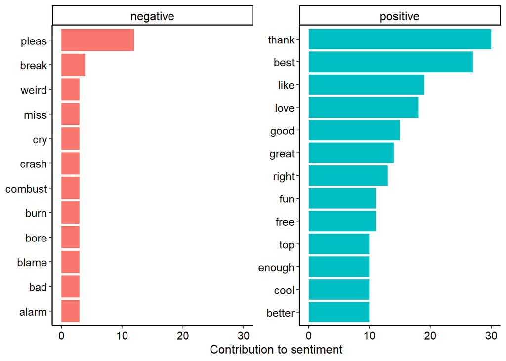

Finally, we obtained a summary sentiment for each tweet, so to get a clear emotion associated to a tweet, taking in consideration the overall positive and negative sentiments recalled in the text.

```
## # A tibble: 6 x 4
##   status_id           positive negative sentiment
##   <chr>                  <int>    <int>     <int>
## 1 1080180385646952448        2        0         2
## 2 1081322680857518080        0        1        -1
## 3 1082723474915844096        2        0         2
## 4 1083035284193726464        1        0         1
## 5 1083410738717179904        2        0         2
## 6 1083832799285538816        1        0         1
```

### Sentiment over Time

We decided to plot the evolution of sentiment overtime.

From this we can see that the most positive tweets were made in September - Novembre 2019, not randomly, as it is the period of time known for the presentation of the Tesla Cybertruck, which went viral for the level of innovation and risk that it represented for the Company.

This sentiment analysis has quite limited insights and takeaways as, being a Company page, tweets are most of the times neutral or slightly positive, but they don’t really include many negative emotions or strong sentiment at all.

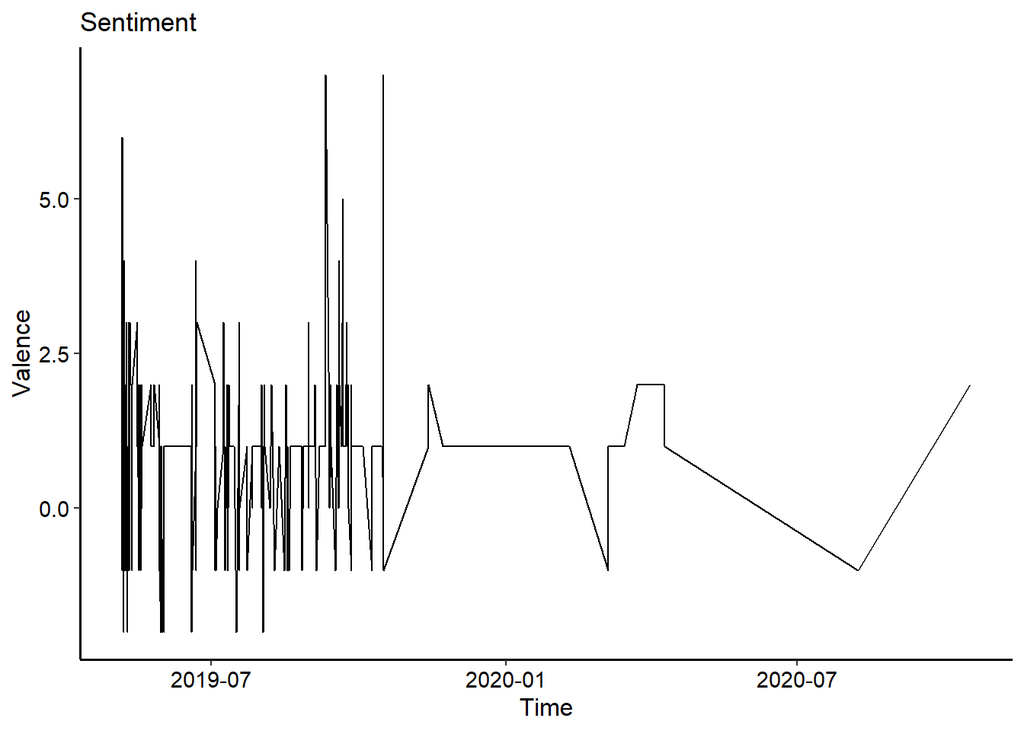

## VI. Concept Analysis

### Main Concepts

We decided to keep the concept analysis simple and effective. For this we decided to implement wordclouds in order to extract just the main ideas that are most frequently evocated in the tweets in analysis.

We did so through the usage of Lemmas and cooccurrences. First with single words:

#### 1 word

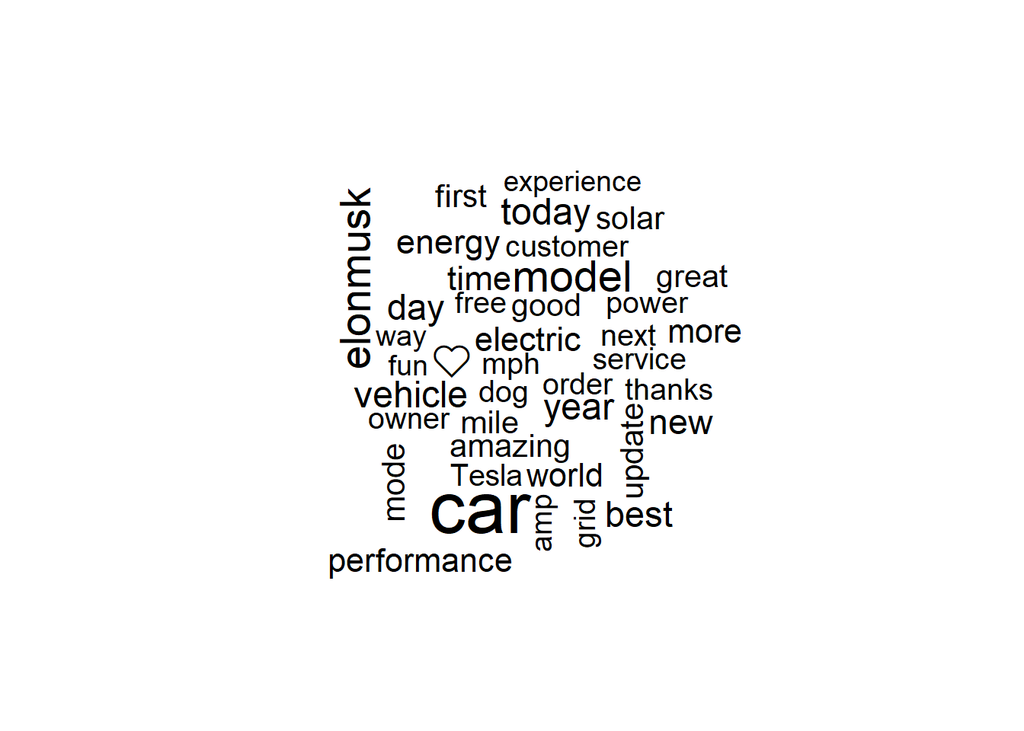

#### Co-occurences

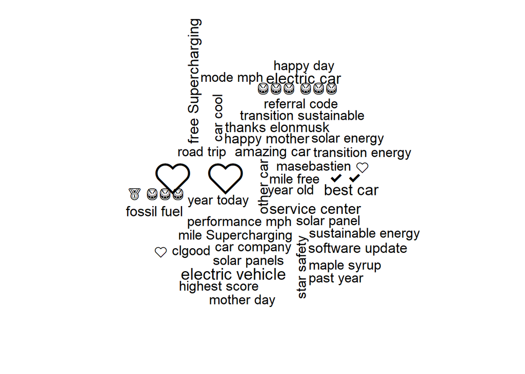

### Limits

**Research and brainstorm about possible solutions / packages:**

1. Collection of Historical Tweets

• Initially, utilized search_fullarchive() function in the rtweet package to collect all the historical tweets of Tesla from the year 2019 to 2020. • Faced difficulty in extracting the same as this is a Premium API option. • After discussion, found an alternate solution and managed to extract the tweets through get_timelines() function in rtweet package, which could collect a maximum of 3200 tweets. • We then subset this dataset from 2019 to 2021 to get the desired dataset.

2. Library Selection for Sentiment Analysis

• At first, planned to perform the Sentiment Analysis using the AFINN dictionary, which represents the sentiments in the range of -5 to +5. • Experienced technically difficulty in loading the text_data package (AFINN dictionary) inside the CoCalc environment. • Resolved this issue by performing the sentiment analysis in RStudio and also extended this analysis using the Bing dictionary. • Compared the results of both dictionaries and found that there is no significant difference. • Finally, as the end results were not compromised, utilized the Bing dictionary to perform the Sentiment Analysis in the CoCalc environment itself.